# Retinalogik vs HFA study JAMA Ophthalmology paper

[Eadie Technologies, Inc.](https://www.eadietech.com/)

2025-06-11

## Setup

### Versioning

Last updated on 2026-Oct-30 at 03:34 PM.

- 2025-Jun-11: Created separate .Rmd file as index.Rmd was getting very cluttered.
- 2025-Jun-26: Extract data based on classification during screening.
- 2025-Aug-25: Extract, clean, and run stats on questionnaire data.
- 2026-Jan-16: Added difference plots, p-value difference plots, LMM etc.
- 2026-Apr-21: Fixed left/eye swap discrepancies and added PSD plots.
- 2026-Oct-28: Added significance testing for Bland-Altman MDs.
- 2026-Oct-30: Added MD misclassification output to csv.

### Acknowledgements

Data collected by Research Assistants Luc St-Pierre, Reann Post, and Research Coordinator Lynn Murphy.

```r
# load packages
library(tidyverse)
```

```r
library(here)
## here() starts at /Users/eadie/EadieTech/retinalogik-study
library(DT)
library(plotly)
library(viridis)
library(svglite)
library(htmltools)
library(gridExtra)
library(sf)
## Linking to GEOS 3.13.0, GDAL 3.8.5, PROJ 9.5.1; sf_use_s2() is TRUE
library(spdep)
library(RColorBrewer)
library(patchwork)
library(report)
library(effectsize)
library(rempsyc)
## Suggested APA citation: Thériault, R. (2023). rempsyc: Convenience functions for psychology.
## Journal of Open Source Software, 8(87), 5466. https://doi.org/10.21105/joss.05466
library(psych)
library(BlandAltmanLeh)
```

```r
# default chunk options
knitr::opts_chunk$set(
  comment = '>', collapse = TRUE, cache = FALSE, dev= c("png")
  )

rm(list = ls())

# load processed data
load(here("dBdat.Rda"))

load(here("retinalogik_hfadatawpsd.Rda"))

classification <- readxl::read_excel("RetinaLogik Data Classification.xlsx") %>%
  mutate(
    # Extract the numeric part after "RL"
    numeric_part = as.numeric(str_extract(ID, "\\d+")),
    # Format the numeric part to have at least two digits with leading zeros
    formatted_numeric = str_pad(numeric_part, width = 2, side = "left", pad = "0"),
    # Combine "RL" with the formatted number
    ID = paste0("RL", formatted_numeric)
  ) %>%
  # Remove the temporary columns
  select(-numeric_part, -formatted_numeric) %>%
  rename(id = ID, classification = Classifcation, eye = `Eye (OD/OS)`) %>%
  mutate(eye = case_when(eye == "OS" ~ "L",
                         eye == "OD" ~ "R",
                         eye == "OU" ~ "R"))

dBdat_filtered <- dBdat %>%
  ungroup() %>%
  mutate(x = as.integer(x), y = as.integer(y)) %>%
  mutate(x = case_when(
    device == "retinalogik" & eye == "L" ~ x*-1,
    TRUE ~ as.integer(x)
  )) %>%
  # remove blind spots
  filter(!(x == 15 & y == -3)) %>%
  filter(!(x == 15 & y == +3)) %>%
  #remove first 2 visits
  #filter(visit != 1 & visit != 2) %>%
  #remove reliability indices <30%
  #filter(flPerc < 30 & fnPerc < 30 & fpPerc < 30) %>%
  group_by(id, device, eye) %>%
  mutate(meanmd = mean(md))

dBdat_filtered <- merge(dBdat_filtered, classification) %>%
  filter(classification != "Control") %>%
  mutate(classification = factor(classification, levels = c("Mild", "Moderate", "Advanced")))
```

### Download plots

[click me to find all generated plots](https://github.com/vvnejl/retinalogik-study/tree/3c8f33e40bc3642df1446c387692c5ecdc15f334/plots)

# Study summary

We compared 24-2 visual field (VF) test results between Retinalogik and the Humphrey Field Analyzer (HFA) using SITA Standard test strategy in patients with early glaucoma and moderate to advanced glaucoma [here](https://vvnejl.github.io/retinalogik-study/). A scotoma analysis was performed following glaucomatous VF definitions found in Park et al. (2011). Scotoma analysis results may be found [here](https://vvnejl.github.io/retinalogik-study/scotoma_analysis.html).

# Methods (very briefly)

## Subjects

Eligible participants were identified among patients of Dr. Brennan Eadie at the Eadie Eye Centre. If deemed eligible for the study, subjects were recruited consecutively.

Each participant underwent five study visits. At each visit, they performed a VF test on both eyes using the two devices. The order of device tested was randomized at the first (baseline) study visit.

Exclusion criteria were:

- age <18 years
- diagnosis of secondary glaucoma
- diagnosis of non-glaucomatous optic neuropathy
- significant media opacity
- previous intraocular surgery
- pregnancy
- seizure disorder
- cardiac pacemaker or other implantable device
- severe vertigo or balance disturbance
- inability to demonstrate competence to make an informed decision regarding study participation

The study adhered to the tenets of the Declaration of Helsinki for research involving human subjects and the protocol was approved by the Nova Scotia Health Research Ethics Board (#1030608). All participants gave their written informed consent before enrollment in the study.

### Demographics

```r
vft <- dBdat_filtered %>%
  distinct(id, visit, eye) %>%
  count(eye)

gender <- dBdat_filtered %>%
  distinct(id, gender) %>%
  count(gender)

groups <- dBdat_filtered %>%
  distinct(id, classification) %>%
  mutate(classification = as.factor(classification)) %>%
  count(classification)
```

All OS data are transposed to OD format before analyses. 255 VF tests from 51 participants (19 females, 32 males) aged 44 to 83 (*M* = 70.16, *SD* = 8.83) were included in the analysis (Early n = 20; Moderate n = 14; Advanced n = 17).

# Results

## Analysis

Of the 5 visits, the first 2 visits were removed from analysis. VFTs where reliability indices (FL, FP, and FN) > 30% were removed from analysis as well.

### Mean/median sensitivity

In patients with advanced glaucoma, the median sensitivity was significantly higher when using the VR-RL perimeter. Wilcoxon signed-rank tests confirmed this difference when looking at the median of the patient-level mean differences between visits.

```r
dBdat_filtered <- dBdat_filtered %>%
  #remove first 2 visits
  filter(visit != 1 & visit != 2) %>%
  #remove reliability indices <30%
  filter(flPerc < 30 & fnPerc < 30 & fpPerc < 30)

dBdat_filtered %>%
  group_by(id, device) %>%
  mutate(mean = mean(dB)) %>%
  distinct(id, classification, device, mean) %>%
  pivot_wider(names_from = device, values_from = mean) %>%
  na.omit() %>%
  mutate(classification = factor(classification, levels = c("Mild", "Moderate", "Advanced"))) %>%
  group_by(classification) %>%
  summarise(
    n = n(),
    mean_retinalogik = mean(retinalogik, na.rm = TRUE),
    sd_retinalogik = sd(retinalogik, na.rm = TRUE),
    mean_hfa = mean(hfa, na.rm = TRUE),
    sd_hfa = sd(hfa, na.rm = TRUE)
  ) %>%
  mutate(difference = mean_retinalogik-mean_hfa) %>%
  nice_table()
```

| classification | n | mean_retinalogik | sd_retinalogik | mean_hfa | sd_hfa | difference |
| --- | --- | --- | --- | --- | --- | --- |
| Mild | 18 | 27.50 | 2.50 | 27.24 | 1.52 | 0.26 |
| Moderate | 13 | 23.02 | 2.03 | 20.79 | 2.33 | 2.23 |
| Advanced | 11 | 17.09 | 6.30 | 13.85 | 5.43 | 3.24 |

```r
#########
dBdat_medians <- dBdat_filtered %>%
  group_by(id, device) %>%
  mutate(median = median(dB)) %>%
  distinct(id, classification, device, median) %>%
  pivot_wider(names_from = device, values_from = median) %>%
  na.omit() %>%
  mutate(difference = retinalogik-hfa)

# 1. Group the cleaned, wide data by classification
wilcoxon_results <- dBdat_medians %>%
  group_by(classification) %>%

  # 2. Nest the data for group-wise application
  nest() %>%

  # 3. Apply the Wilcoxon test to the paired columns in each nested group
  mutate(
    wilcox_test = map(data, ~ wilcox.test(.x$retinalogik, .x$hfa, paired = TRUE)),

    # 4. Extract the key results cleanly
    W_statistic = map_dbl(wilcox_test, "statistic"),
    p_value = map_dbl(wilcox_test, "p.value")
  ) %>%

  # 5. Select the final output columns
  select(classification, W_statistic, p_value)

wilcoxon_results %>%
  mutate(classification = factor(classification, levels = c("Mild", "Moderate", "Advanced"))) %>%
  arrange(classification) %>%
  nice_table(title = c("Wilcoxon signed rank test on paired samples"))
```

| Wilcoxon signed rank test on paired samples classification | Wilcoxon signed rank test on paired samples W_statistic | Wilcoxon signed rank test on paired samples p_value |
| --- | --- | --- |
| Mild | 78.50 | 0.78 |
| Moderate | 62.00 | 0.25 |
| Advanced | 63.00 | 0.00 |

```r
dBdat_filtered %>%
  group_by(id, device) %>%
  mutate(median = median(dB)) %>%
  distinct(id, classification, device, median) %>%
  pivot_wider(names_from = device, values_from = median) %>%
  na.omit() %>%
  mutate(classification = factor(classification, levels = c("Mild", "Moderate", "Advanced"))) %>%
  group_by(classification) %>%
  summarise(
    n = n(),
    median_retinalogik = median(retinalogik, na.rm = TRUE),
    q1_retinalogik = quantile(retinalogik, .25, na.rm = TRUE),
    q3_retinalogik = quantile(retinalogik, .75, na.rm = TRUE),
    iqr_retinalogik = IQR(retinalogik, na.rm = TRUE),
    median_hfa = median(hfa, na.rm = TRUE),
    q1_hfa = quantile(hfa, .25, na.rm = TRUE),
    q3_hfa = quantile(hfa, .75, na.rm = TRUE),
    iqr_hfa = IQR(hfa, na.rm = TRUE)
  ) %>%
  nice_table()
```

| classification | n | median_retinalogik | q1_retinalogik | q3_retinalogik | iqr_retinalogik | median_hfa | q1_hfa | q3_hfa | iqr_hfa |
| --- | --- | --- | --- | --- | --- | --- | --- | --- | --- |
| Mild | 18 | 28.00 | 26.00 | 30.00 | 4.00 | 28.00 | 28.00 | 29.00 | 1.00 |
| Moderate | 13 | 24.50 | 24.00 | 26.50 | 2.50 | 25.00 | 22.00 | 26.00 | 4.00 |
| Advanced | 11 | 22.00 | 18.50 | 24.00 | 5.50 | 17.50 | 10.50 | 19.50 | 9.00 |

```r
# mild_data <- subset(dBdat_means, classification == "Mild")
# t.test(mild_data$retinalogik, mild_data$hfa, paired = TRUE) %>%
#   report()
#
# moderate_data <- subset(dBdat_means, classification == "Moderate")
# t.test(moderate_data$retinalogik, moderate_data$hfa, paired = TRUE) %>%
#   report()
#
# advanced_data <- subset(dBdat_means, classification == "Advanced")
# t.test(advanced_data$retinalogik, advanced_data$hfa, paired = TRUE) %>%
#   report() %>% summary()
#
# dBdat_medians <- dBdat_filtered %>%
#   group_by(id, device) %>%
#   mutate(median = median(dB)) %>%
#   distinct(id, classification, device, median) %>%
#   pivot_wider(names_from = device, values_from = median) %>%
#   na.omit()
#
# mild_tmp <- dBdat_filtered %>%
#   subset(classification == "Mild") %>%
#   pivot_wider(names_from = device, values_from = dB) %>%
#   na.omit()
# wilcox.test(mild_tmp$retinalogik, mild_tmp$hfa, paired=TRUE)
#
# mild_data <- subset(dBdat_medians, classification == "Mild")
# wilcox.test(mild_data$retinalogik, mild_data$hfa, paired = TRUE)
#
# moderate_data <- subset(dBdat_medians, classification == "Moderate")
# wilcox.test(moderate_data$retinalogik, moderate_data$hfa, paired = TRUE)
#
# advanced_data <- subset(dBdat_medians, classification == "Advanced")
# wilcox.test(advanced_data$retinalogik, advanced_data$hfa, paired = TRUE)
```

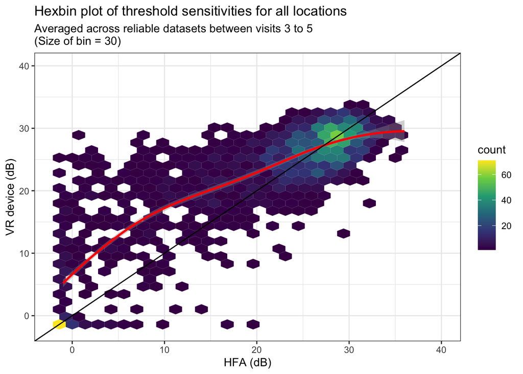

```r
dBdat_filtered %>%
  group_by(id, device, x, y) %>%
  mutate(meandB = mean(dB)) %>%
  distinct(id, device, x, y, meandB) %>%
  pivot_wider(names_from = device, values_from = meandB) %>%
  mutate(retinalogik = as.numeric(retinalogik), hfa = as.numeric(hfa)) %>%
  ggplot(aes(x = hfa, y = retinalogik)) +
  geom_hex(bins = 30) +
  scale_fill_viridis_c() +
  geom_smooth(method = "loess", se = TRUE, colour = "red") +
  geom_abline(intercept = 0, slope = 1) +
  labs(title="Hexbin plot of threshold sensitivities for all locations",
       subtitle="Averaged across reliable datasets between visits 3 to 5\n(Size of bin = 30)") +
  xlab("HFA (dB)") +
  ylab("VR device (dB)") +
  xlim(-2, 40) +
  ylim(-2, 40) +
  theme_bw()
> Warning: Removed 416 rows containing non-finite outside the scale range
> (`stat_binhex()`).
> `geom_smooth()` using formula = 'y ~ x'
> Warning: Removed 416 rows containing non-finite outside the scale range
> (`stat_smooth()`).
```

```r
#ggsave("plots/hexbin30.png", width = 5, height = 4)
```

[figure not shown]

```r
df <- dBdat_filtered %>%
  group_by(id, device, x, y) %>%
  mutate(dB = mean(dB)) %>%
  distinct(id, device, x, y, dB) %>%
  pivot_wider(names_from = device, values_from = dB) %>%
  mutate(retinalogik = as.numeric(retinalogik), hfa = as.numeric(hfa))

blandplot <- bland.altman.plot(df$retinalogik, df$hfa, graph.sys = "ggplot2", geom_count=T)
> Warning: Using `size` aesthetic for lines was deprecated in ggplot2 3.4.0.
> ℹ Please use `linewidth` instead.
> ℹ The deprecated feature was likely used in the BlandAltmanLeh package.
>   Please report the issue to the authors.
> This warning is displayed once per session.
> Call `lifecycle::last_lifecycle_warnings()` to see where this warning was
> generated.
bias <- mean(df$retinalogik, na.rm=T) - mean(df$hfa, na.rm=T)

print(blandplot +
        geom_smooth(method = "lm", se = FALSE) +
        # geom_point(position = "jitter") +
        geom_hline(yintercept = 0, color = "black") +
        geom_hline(yintercept = bias, color = "red", linetype = "solid", linewidth = 1) +
        #ylim(c(-10, 10)) +
        xlab("Threshold sensitivity (dB)") +
        ylab("Difference in dB (VR device-HFA)") +
        labs(subtitle=paste("Bias =", round(bias, 2), "dB")) +
        ggtitle("Bland-Altman plot comparing threshold sensitivity across all stages of glaucoma"))
> `geom_smooth()` using formula = 'y ~ x'
```

```r
#ggsave("plots/blandaltman-dB-allgon.png", width = 7, height = 5)
```

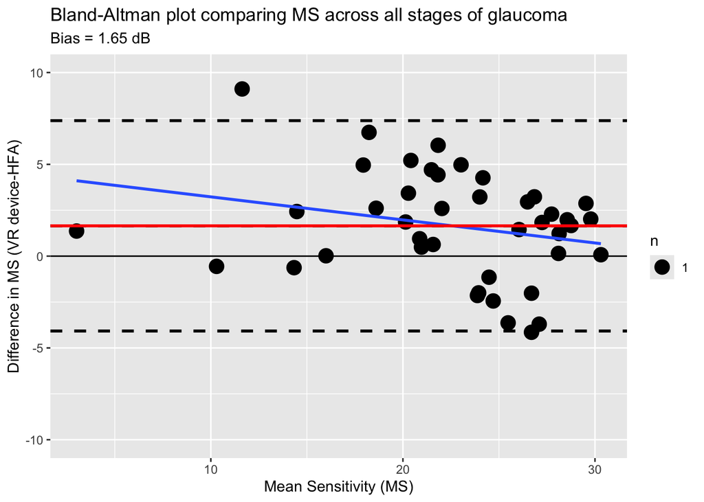

```r
ms_means <- dBdat_filtered %>%
  group_by(id, device, visit) %>%
  summarize(ms = mean(dB)) %>%
  group_by(id, device) %>%
  summarize(meanms = mean(ms)) %>%
  pivot_wider(names_from = device, values_from = meanms) %>%
  na.omit() %>%
  mutate(difference = retinalogik-hfa)
> `summarise()` has regrouped the output.
> `summarise()` has regrouped the output.
> ℹ Summaries were computed grouped by id, device, and visit.
> ℹ Output is grouped by id and device.
> ℹ Use `summarise(.groups = "drop_last")` to silence this message.
> ℹ Use `summarise(.by = c(id, device, visit))` for per-operation grouping
>   (`?dplyr::dplyr_by`) instead.

df <- ms_means

blandplot <- bland.altman.plot(df$retinalogik, df$hfa, graph.sys = "ggplot2", geom_count=T)
bias <- mean(df$retinalogik, na.rm=T) - mean(df$hfa, na.rm=T)

print(blandplot +
        geom_smooth(method = "lm", se = FALSE) +
        # geom_point(position = "jitter") +
        geom_hline(yintercept = 0, color = "black") +
        geom_hline(yintercept = bias, color = "red", linetype = "solid", linewidth = 1) +
        ylim(c(-10, 10)) +
        xlab("Mean Sensitivity (MS)") +
        ylab("Difference in MS (VR device-HFA)") +
        labs(subtitle=paste("Bias =", round(bias, 2), "dB")) +
        ggtitle("Bland-Altman plot comparing MS across all stages of glaucoma"))
> `geom_smooth()` using formula = 'y ~ x'
```

```r
#ggsave("plots/blandaltman-ms-allgon.png", width = 7, height = 5)
```

### Mean deviation

In patients with moderate and advanced glaucoma, the mean deviation was significantly higher when using the VR-RL perimeter. Wilcoxon signed-rank tests confirmed this difference when looking at the median of the patient-level mean differences between visits.

```r
dBdat_filtered %>%
  group_by(id, device) %>%
  mutate(mean = mean(md)) %>%
  distinct(id, classification, device, mean) %>%
  pivot_wider(names_from = device, values_from = mean) %>%
  na.omit() %>%
  mutate(classification = factor(classification, levels = c("Mild", "Moderate", "Advanced"))) %>%
  group_by(classification) %>%
  summarise(
    n = n(),
    mean_retinalogik = mean(retinalogik, na.rm = TRUE),
    sd_retinalogik = sd(retinalogik, na.rm = TRUE),
    mean_hfa = mean(hfa, na.rm = TRUE),
    sd_hfa = sd(hfa, na.rm = TRUE)
  ) %>%
  mutate(difference = mean_retinalogik-mean_hfa) %>%
  nice_table()
```

| classification | n | mean_retinalogik | sd_retinalogik | mean_hfa | sd_hfa | difference |
| --- | --- | --- | --- | --- | --- | --- |
| Mild | 18 | -2.40 | 2.30 | -2.09 | 1.30 | -0.30 |
| Moderate | 13 | -6.60 | 1.92 | -8.38 | 2.14 | 1.78 |
| Advanced | 11 | -12.81 | 6.29 | -16.39 | 5.65 | 3.58 |

```r
#########
md_means <- dBdat_filtered %>%
  group_by(id, device) %>%
  mutate(mean = mean(md)) %>%
  distinct(id, classification, device, mean) %>%
  pivot_wider(names_from = device, values_from = mean) %>%
  na.omit() %>%
  mutate(difference = retinalogik-hfa)

md_medians <- dBdat_filtered %>%
  group_by(id, device) %>%
  mutate(median = median(md)) %>%
  distinct(id, classification, device, median) %>%
  pivot_wider(names_from = device, values_from = median) %>%
  na.omit() %>%
  mutate(difference = retinalogik-hfa)

# 1. Group the cleaned, wide data by classification
wilcoxon_results <- md_medians %>%
  group_by(classification) %>%

  # 2. Nest the data for group-wise application
  nest() %>%

  # 3. Apply the Wilcoxon test to the paired columns in each nested group
  mutate(
    wilcox_test = map(data, ~ wilcox.test(.x$retinalogik, .x$hfa, paired = TRUE)),

    # 4. Extract the key results cleanly
    W_statistic = map_dbl(wilcox_test, "statistic"),
    p_value = map_dbl(wilcox_test, "p.value")
  ) %>%

  # 5. Select the final output columns
  select(classification, W_statistic, p_value)

wilcoxon_results %>%
  mutate(classification = factor(classification, levels = c("Mild", "Moderate", "Advanced"))) %>%
  arrange(classification) %>%
  nice_table(title = c("Wilcoxon signed rank test on paired samples"))
```

| Wilcoxon signed rank test on paired samples classification | Wilcoxon signed rank test on paired samples W_statistic | Wilcoxon signed rank test on paired samples p_value |
| --- | --- | --- |
| Mild | 77.00 | 0.73 |
| Moderate | 74.00 | 0.05 |
| Advanced | 63.00 | 0.00 |

```r
dBdat_filtered %>%
  group_by(id, device) %>%
  mutate(median = median(md)) %>%
  distinct(id, classification, device, median) %>%
  pivot_wider(names_from = device, values_from = median) %>%
  na.omit() %>%
  mutate(classification = factor(classification, levels = c("Mild", "Moderate", "Advanced"))) %>%
  group_by(classification) %>%
  summarise(
    n = n(),
    median_retinalogik = median(retinalogik, na.rm = TRUE),
    q1_retinalogik = quantile(retinalogik, .25, na.rm = TRUE),
    q3_retinalogik = quantile(retinalogik, .75, na.rm = TRUE),
    iqr_retinalogik = IQR(retinalogik, na.rm = TRUE),
    median_hfa = median(hfa, na.rm = TRUE),
    q1_hfa = quantile(hfa, .25, na.rm = TRUE),
    q3_hfa = quantile(hfa, .75, na.rm = TRUE),
    iqr_hfa = IQR(hfa, na.rm = TRUE)
  ) %>%
  nice_table()
```

| classification | n | median_retinalogik | q1_retinalogik | q3_retinalogik | iqr_retinalogik | median_hfa | q1_hfa | q3_hfa | iqr_hfa |
| --- | --- | --- | --- | --- | --- | --- | --- | --- | --- |
| Mild | 18 | -1.39 | -4.36 | -0.97 | 3.38 | -1.73 | -2.90 | -1.21 | 1.69 |
| Moderate | 13 | -7.08 | -8.31 | -5.30 | 3.01 | -8.52 | -9.10 | -7.28 | 1.82 |
| Advanced | 11 | -13.46 | -15.00 | -7.50 | 7.50 | -15.24 | -19.14 | -12.58 | 6.56 |

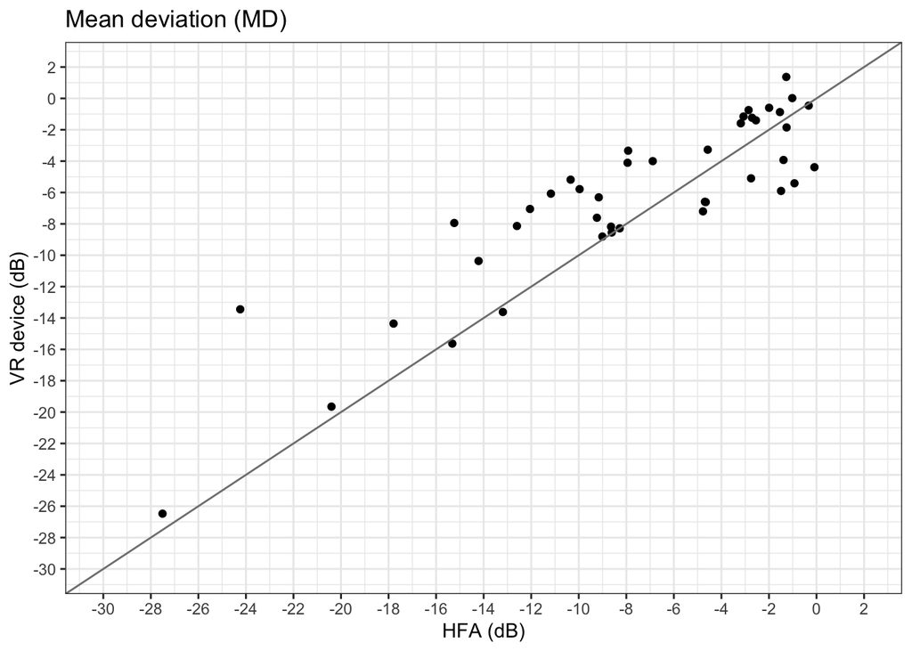

```r
dBdat_filtered %>%
  group_by(id, device, visit) %>%
  summarize(md = mean(md)) %>%
  group_by(id, device) %>%
  summarize(meanmd = mean(md)) %>%
  pivot_wider(names_from = device, values_from = meanmd) %>%
  mutate(retinalogik = as.numeric(retinalogik), hfa = as.numeric(hfa)) %>%
  ggplot(., aes(x=hfa, y=retinalogik)) +
  geom_point(position = "jitter") +
  scale_x_continuous(breaks = seq(-30, 2, by=2), limits=c(-30,2)) +
  scale_y_continuous(breaks = seq(-30, 2, by=2), limits=c(-30,2)) +
  geom_abline(intercept = 0, slope = 1, color = "gray50") +
  labs(title="Mean deviation (MD)") +
  xlab("HFA (dB)") +
  ylab("VR device (dB)") +
  theme_bw()
> `summarise()` has regrouped the output.
> `summarise()` has regrouped the output.
> ℹ Summaries were computed grouped by id, device, and visit.
> ℹ Output is grouped by id and device.
> ℹ Use `summarise(.groups = "drop_last")` to silence this message.
> ℹ Use `summarise(.by = c(id, device, visit))` for per-operation grouping
>   (`?dplyr::dplyr_by`) instead.
> Warning: Removed 8 rows containing missing values or values outside the scale range
> (`geom_point()`).
```

```r
#ggsave("plots/mdscatter.png", width = 5, height = 4)
```

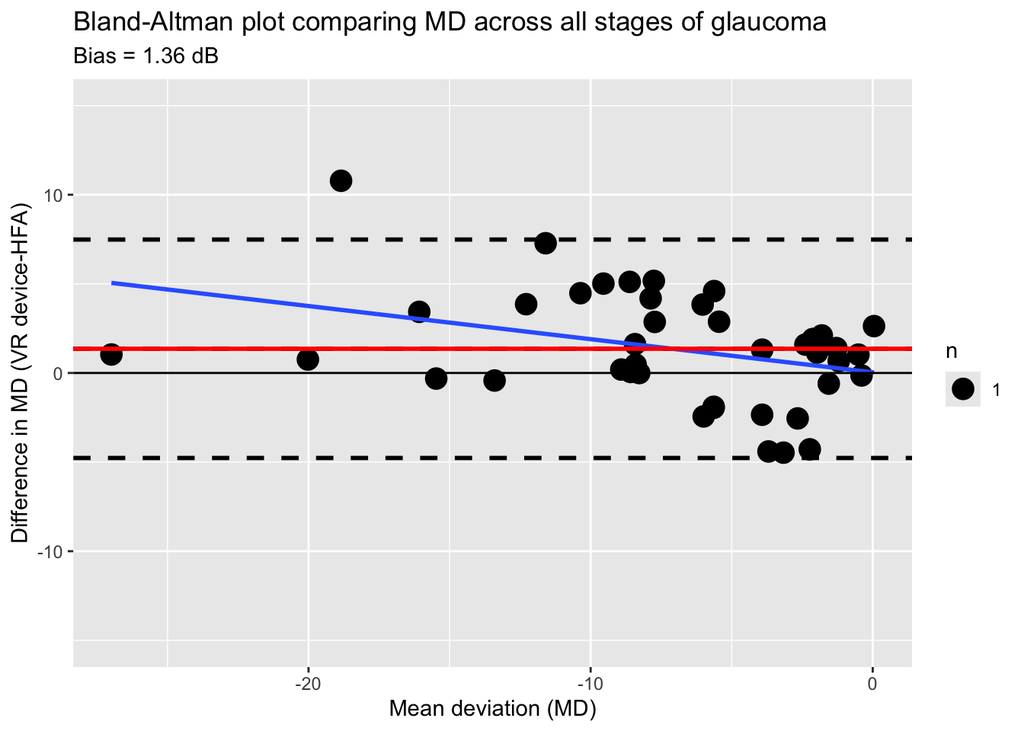

```r
library(BlandAltmanLeh)

df <- md_means

blandplot <- bland.altman.plot(df$retinalogik, df$hfa, graph.sys = "ggplot2", geom_count=T)
bias <- mean(df$retinalogik, na.rm=T) - mean(df$hfa, na.rm=T)

# Calculate differences and averages
differences <- df$retinalogik - df$hfa
averages <- (df$retinalogik + df$hfa) / 2

# 1. Test for Fixed/Systematic Bias (One-sample t-test against mu = 0)
bias_test <- t.test(differences, mu = 0)
print(bias_test)
>
>   One Sample t-test
>
> data:  differences
> t = 2.8155, df = 41, p-value = 0.007453
> alternative hypothesis: true mean is not equal to 0
> 95 percent confidence interval:
>  0.3839755 2.3325324
> sample estimates:
> mean of x
>  1.358254

# 2. Test for Proportional Bias (Linear regression of differences on averages)
prop_bias_test <- lm(differences ~ averages)
summary(prop_bias_test)
>
> Call:
> lm(formula = differences ~ averages)
>
> Residuals:
>    Min     1Q Median     3Q    Max
> -5.128 -2.975  0.475  1.803  7.244
>
> Coefficients:
>             Estimate Std. Error t value Pr(>|t|)
> (Intercept)  0.03785    0.71912   0.053   0.9583
> averages    -0.18589    0.07815  -2.379   0.0222 *
> ---
> Signif. codes:  0 '***' 0.001 '**' 0.01 '*' 0.05 '.' 0.1 ' ' 1
>
> Residual standard error: 2.963 on 40 degrees of freedom
> Multiple R-squared:  0.1239,  Adjusted R-squared:  0.102
> F-statistic: 5.658 on 1 and 40 DF,  p-value: 0.02224

print(blandplot +
        geom_smooth(method = "lm", se = FALSE) +
        # geom_point(position = "jitter") +
        geom_hline(yintercept = 0, color = "black") +
        geom_hline(yintercept = bias, color = "red", linetype = "solid", linewidth = 1) +
        ylim(c(-15, 15)) +
        xlab("Mean deviation (MD)") +
        ylab("Difference in MD (VR device-HFA)") +
        labs(subtitle=paste("Bias =", round(bias, 2), "dB")) +
        ggtitle("Bland-Altman plot comparing MD across all stages of glaucoma"))
> `geom_smooth()` using formula = 'y ~ x'
```

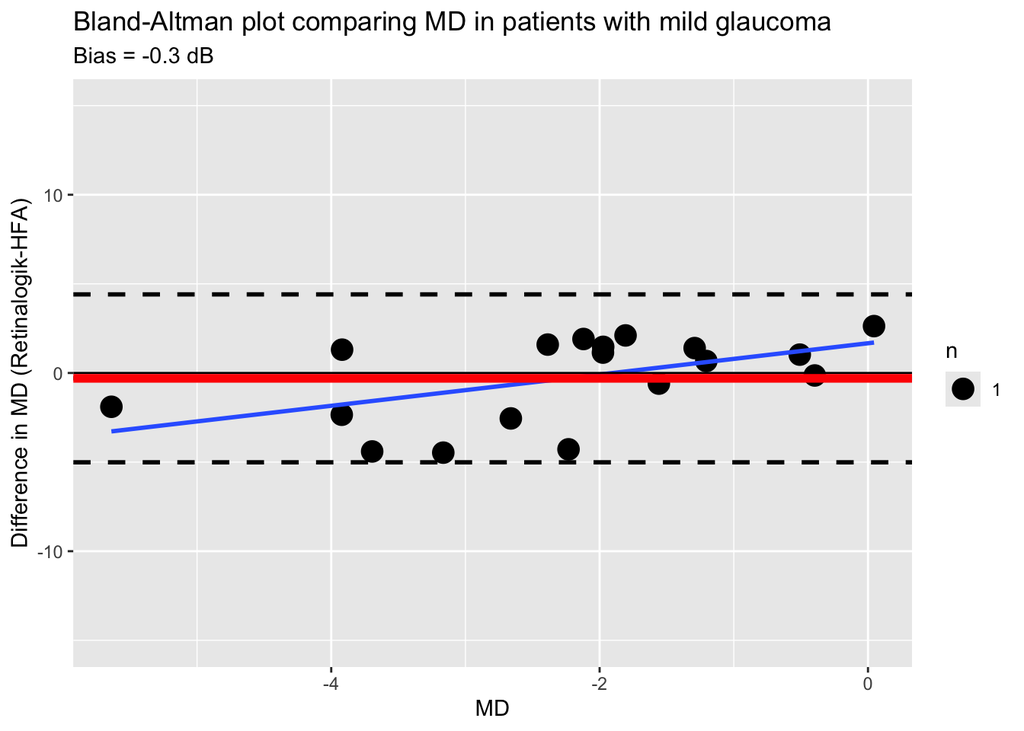

```r
#ggsave("plots/blandaltman-md-allgon.png", width = 7, height = 5)

milddf <- df %>%
  filter(classification == "Mild")

blandplotmild <- bland.altman.plot(milddf$retinalogik, milddf$hfa, graph.sys = "ggplot2", geom_count=T)
biasmild <- mean(milddf$retinalogik, na.rm=T) - mean(milddf$hfa, na.rm=T)

 print(blandplotmild +
        geom_smooth(method = "lm", se = FALSE) +
        # geom_point(position = "jitter") +
        geom_hline(yintercept = 0, color = "black") +
        geom_hline(yintercept = biasmild, color = "red", linetype = "solid", linewidth = 2) +
        ylim(c(-15, 15)) +
        xlab("MD") +
        ylab("Difference in MD (Retinalogik-HFA)") +
        labs(subtitle=paste("Bias =", round(biasmild, 2), "dB")) +
        ggtitle("Bland-Altman plot comparing MD in patients with mild glaucoma"))
> `geom_smooth()` using formula = 'y ~ x'
```

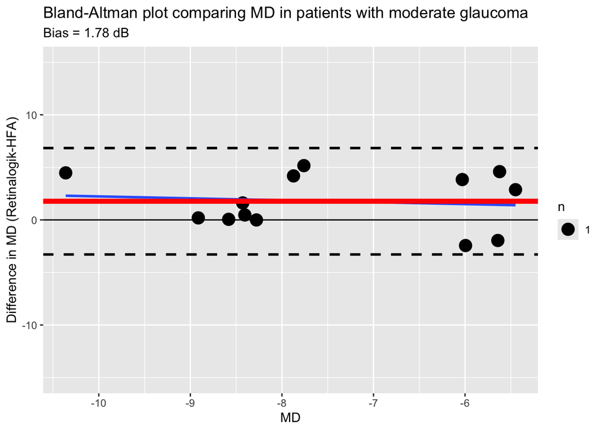

```r
#ggsave("plots/blandaltman-md-mild.png", width = 7, height = 5)

moderatedf <- df %>%
  filter(classification == "Moderate")

blandplotmoderate <- bland.altman.plot(moderatedf$retinalogik, moderatedf$hfa, graph.sys = "ggplot2", geom_count=T)
biasmoderate <- mean(moderatedf$retinalogik, na.rm=T) - mean(moderatedf$hfa, na.rm=T)

print(blandplotmoderate +
        geom_smooth(method = "lm", se = FALSE) +
        # geom_point(position = "jitter") +
        geom_hline(yintercept = 0, color = "black") +
        geom_hline(yintercept = biasmoderate, color = "red", linetype = "solid", linewidth = 2) +
        ylim(c(-15, 15)) +
        xlab("MD") +
        ylab("Difference in MD (Retinalogik-HFA)") +
        labs(subtitle=paste("Bias =", round(biasmoderate, 2), "dB")) +
        ggtitle("Bland-Altman plot comparing MD in patients with moderate glaucoma"))
> `geom_smooth()` using formula = 'y ~ x'
```

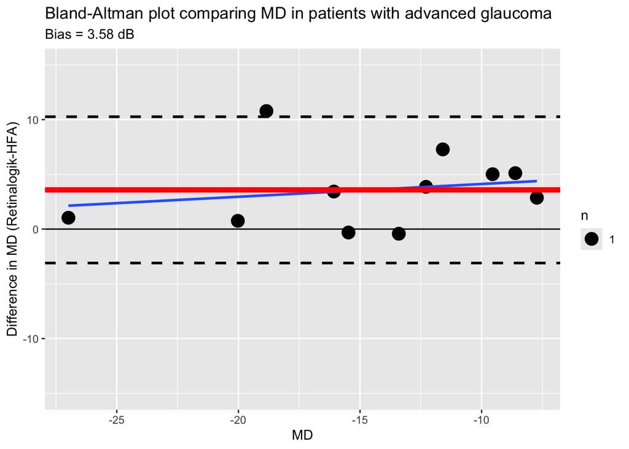

```r
#ggsave("plots/blandaltman-md-moderate.png", width = 7, height = 5)

advanceddf <- df %>%
  filter(classification == "Advanced")

blandplotadvanced <- bland.altman.plot(advanceddf$retinalogik, advanceddf$hfa, graph.sys = "ggplot2", geom_count=T)
biasadvanced <- mean(advanceddf$retinalogik, na.rm=T) - mean(advanceddf$hfa, na.rm=T)

print(blandplotadvanced +
        geom_smooth(method = "lm", se = FALSE) +
        # geom_point(position = "jitter") +
        geom_hline(yintercept = 0, color = "black") +
        geom_hline(yintercept = biasadvanced, color = "red", linetype = "solid", linewidth = 2) +
        ylim(c(-15, 15)) +
        xlab("MD") +
        ylab("Difference in MD (Retinalogik-HFA)") +
        labs(subtitle=paste("Bias =", round(biasadvanced, 2), "dB")) +
        ggtitle("Bland-Altman plot comparing MD in patients with advanced glaucoma"))
> `geom_smooth()` using formula = 'y ~ x'
```

```r
#ggsave("plots/blandaltman-md-advanced.png", width = 7, height = 5)
```

```r
tmp <- df %>% mutate(
    rl_classification = case_when(
      retinalogik < -12 ~ "Advanced (< -12)",
      retinalogik >= -12 & retinalogik < -6 ~ "Moderate (-6 to -12)",
      retinalogik >= -6 ~ "Mild (> -6)",
      TRUE ~ "Above 0 (> 0)" # Catches any positive values (e.g., RL04, RL12)
    )
  )

#write.csv(tmp, "misclassification.csv")
```

### Pattern standard deviation

In patients with moderate and advanced glaucoma, the pattern standard deviation was significantly lower when using the VR-RL perimeter. Wilcoxon signed-rank tests confirmed this difference when looking at the median of the patient-level mean differences between visits.

```r
dBdat_filtered %>%
  group_by(id, device) %>%
  mutate(mean = mean(psd)) %>%
  distinct(id, classification, device, mean) %>%
  pivot_wider(names_from = device, values_from = mean) %>%
  na.omit() %>%
  mutate(classification = factor(classification, levels = c("Mild", "Moderate", "Advanced"))) %>%
  group_by(classification) %>%
  summarise(
    n = n(),
    mean_retinalogik = mean(retinalogik, na.rm = TRUE),
    sd_retinalogik = sd(retinalogik, na.rm = TRUE),
    mean_hfa = mean(hfa, na.rm = TRUE),
    sd_hfa = sd(hfa, na.rm = TRUE)
  ) %>%
  mutate(difference = mean_retinalogik-mean_hfa) %>%
  nice_table()
```

| classification | n | mean_retinalogik | sd_retinalogik | mean_hfa | sd_hfa | difference |
| --- | --- | --- | --- | --- | --- | --- |
| Mild | 18 | 3.13 | 1.59 | 4.00 | 2.84 | -0.87 |
| Moderate | 13 | 6.32 | 1.15 | 9.50 | 2.24 | -3.17 |
| Advanced | 11 | 9.01 | 2.33 | 11.28 | 2.14 | -2.27 |

```r
#########
psd_means <- dBdat_filtered %>%
  group_by(id, device) %>%
  mutate(mean = mean(psd)) %>%
  distinct(id, classification, device, mean) %>%
  pivot_wider(names_from = device, values_from = mean) %>%
  na.omit() %>%
  mutate(difference = retinalogik-hfa)

psd_medians <- dBdat_filtered %>%
  group_by(id, device) %>%
  mutate(median = median(psd)) %>%
  distinct(id, classification, device, median) %>%
  pivot_wider(names_from = device, values_from = median) %>%
  na.omit() %>%
  mutate(difference = retinalogik-hfa)

# 1. Group the cleaned, wide data by classification
wilcoxon_results <- psd_medians %>%
  group_by(classification) %>%

  # 2. Nest the data for group-wise application
  nest() %>%

  # 3. Apply the Wilcoxon test to the paired columns in each nested group
  mutate(
    wilcox_test = map(data, ~ wilcox.test(.x$retinalogik, .x$hfa, paired = TRUE)),

    # 4. Extract the key results cleanly
    W_statistic = map_dbl(wilcox_test, "statistic"),
    p_value = map_dbl(wilcox_test, "p.value")
  ) %>%

  # 5. Select the final output columns
  select(classification, W_statistic, p_value)

wilcoxon_results %>%
  mutate(classification = factor(classification, levels = c("Mild", "Moderate", "Advanced"))) %>%
  arrange(classification) %>%
  nice_table(title = c("Wilcoxon signed rank test on paired samples"))
```

| Wilcoxon signed rank test on paired samples classification | Wilcoxon signed rank test on paired samples W_statistic | Wilcoxon signed rank test on paired samples p_value |
| --- | --- | --- |
| Mild | 52.50 | 0.16 |
| Moderate | 0.00 | 0.00 |
| Advanced | 2.00 | 0.00 |

```r
dBdat_filtered %>%
  group_by(id, device) %>%
  mutate(median = median(psd)) %>%
  distinct(id, classification, device, median) %>%
  pivot_wider(names_from = device, values_from = median) %>%
  na.omit() %>%
  mutate(classification = factor(classification, levels = c("Mild", "Moderate", "Advanced"))) %>%
  group_by(classification) %>%
  summarise(
    n = n(),
    median_retinalogik = median(retinalogik, na.rm = TRUE),
    q1_retinalogik = quantile(retinalogik, .25, na.rm = TRUE),
    q3_retinalogik = quantile(retinalogik, .75, na.rm = TRUE),
    iqr_retinalogik = IQR(retinalogik, na.rm = TRUE),
    median_hfa = median(hfa, na.rm = TRUE),
    q1_hfa = quantile(hfa, .25, na.rm = TRUE),
    q3_hfa = quantile(hfa, .75, na.rm = TRUE),
    iqr_hfa = IQR(hfa, na.rm = TRUE)
  ) %>%
  nice_table()
```

| classification | n | median_retinalogik | q1_retinalogik | q3_retinalogik | iqr_retinalogik | median_hfa | q1_hfa | q3_hfa | iqr_hfa |
| --- | --- | --- | --- | --- | --- | --- | --- | --- | --- |
| Mild | 18 | 2.33 | 1.93 | 3.60 | 1.68 | 2.67 | 1.87 | 5.86 | 3.98 |
| Moderate | 13 | 6.33 | 5.80 | 7.35 | 1.54 | 9.40 | 8.60 | 10.27 | 1.67 |
| Advanced | 11 | 8.71 | 7.75 | 10.31 | 2.56 | 10.87 | 9.53 | 12.78 | 3.25 |

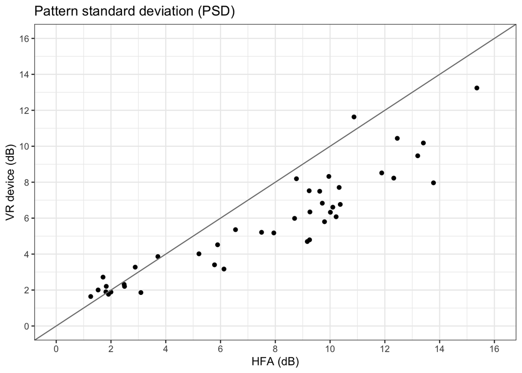

```r
dBdat_filtered %>%
  group_by(id, device, visit) %>%
  summarize(psd = mean(psd)) %>%
  group_by(id, device) %>%
  summarize(meanpsd = mean(psd)) %>%
  pivot_wider(names_from = device, values_from = meanpsd) %>%
  mutate(retinalogik = as.numeric(retinalogik), hfa = as.numeric(hfa)) %>%
  ggplot(., aes(x=hfa, y=retinalogik)) +
  geom_point(position = "jitter") +
  scale_x_continuous(breaks = seq(0, 16, by=2), limits=c(0,16)) +
  scale_y_continuous(breaks = seq(0, 16, by=2), limits=c(0,16)) +
  geom_abline(intercept = 0, slope = 1, color = "gray50") +
  labs(title="Pattern standard deviation (PSD)") +
  xlab("HFA (dB)") +
  ylab("VR device (dB)") +
  theme_bw()
> `summarise()` has regrouped the output.
> `summarise()` has regrouped the output.
> ℹ Summaries were computed grouped by id, device, and visit.
> ℹ Output is grouped by id and device.
> ℹ Use `summarise(.groups = "drop_last")` to silence this message.
> ℹ Use `summarise(.by = c(id, device, visit))` for per-operation grouping
>   (`?dplyr::dplyr_by`) instead.
> Warning: Removed 8 rows containing missing values or values outside the scale range
> (`geom_point()`).
```

```r
#ggsave("plots/psdscatter.png", width = 5, height = 4)
```

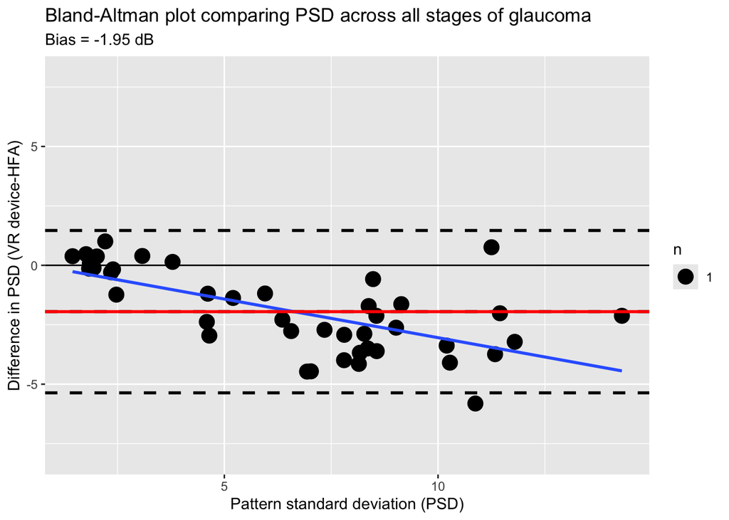

```r
df <- psd_means

blandplot <- bland.altman.plot(df$retinalogik, df$hfa, graph.sys = "ggplot2", geom_count=T)
bias <- mean(df$retinalogik, na.rm=T) - mean(df$hfa, na.rm=T)

print(blandplot +
        geom_smooth(method = "lm", se = FALSE) +
        # geom_point(position = "jitter") +
        geom_hline(yintercept = 0, color = "black") +
        geom_hline(yintercept = bias, color = "red", linetype = "solid", linewidth = 1) +
        ylim(c(-8, 8)) +
        xlab("Pattern standard deviation (PSD)") +
        ylab("Difference in PSD (VR device-HFA)") +
        labs(subtitle=paste("Bias =", round(bias, 2), "dB")) +
        ggtitle("Bland-Altman plot comparing PSD across all stages of glaucoma"))
> `geom_smooth()` using formula = 'y ~ x'
```

```r
#ggsave("plots/blandaltman-psd-allgon.png", width = 7, height = 5)
```

### Pointwise analysis

```r
# Calculate eccentricity for each test point
dBdat_filtered$eccentricity <- sqrt(dBdat_filtered$x^2 + dBdat_filtered$y^2)

library(lme4)
> Loading required package: Matrix
>
> Attaching package: 'Matrix'
> The following objects are masked from 'package:tidyr':
>
>     expand, pack, unpack
library(lmerTest) # Adds p-values to lmer output
>
> Attaching package: 'lmerTest'
> The following object is masked from 'package:lme4':
>
>     lmer
> The following object is masked from 'package:stats':
>
>     step

# The model
lmm_model <- lmer(dB ~ device * classification + eccentricity + visit +
                       (1 + visit | id),
                       data = dBdat_filtered)

summary(lmm_model)
> Linear mixed model fit by REML. t-tests use Satterthwaite's method [
> lmerModLmerTest]
> Formula: dB ~ device * classification + eccentricity + visit + (1 + visit |
>     id)
>    Data: dBdat_filtered
>
> REML criterion at convergence: 83793.3
>
> Scaled residuals:
>     Min      1Q  Median      3Q     Max
> -4.1062 -0.3507  0.1212  0.5640  3.8925
>
> Random effects:
>  Groups   Name        Variance Std.Dev. Corr
>  id       (Intercept) 17.1566  4.1421
>           visit        0.2113  0.4596   -0.50
>  Residual             51.5593  7.1805
> Number of obs: 12324, groups:  id, 50
>
> Fixed effects:
>                                            Estimate Std. Error         df
> (Intercept)                               3.098e+01  9.501e-01  6.332e+01
> deviceretinalogik                         2.183e-01  2.057e-01  1.152e+04
> classificationModerate                   -6.368e+00  1.278e+00  4.804e+01
> classificationAdvanced                   -1.533e+01  1.230e+00  4.810e+01
> eccentricity                             -2.030e-01  1.075e-02  1.222e+04
> visit                                    -7.427e-02  1.053e-01  4.497e+01
> deviceretinalogik:classificationModerate  1.919e+00  3.211e-01  1.108e+04
> deviceretinalogik:classificationAdvanced  3.163e+00  3.625e-01  9.744e+03
>                                          t value Pr(>|t|)
> (Intercept)                               32.603  < 2e-16 ***
> deviceretinalogik                          1.061    0.289
> classificationModerate                    -4.983 8.52e-06 ***
> classificationAdvanced                   -12.455  < 2e-16 ***
> eccentricity                             -18.885  < 2e-16 ***
> visit                                     -0.705    0.484
> deviceretinalogik:classificationModerate   5.978 2.33e-09 ***
> deviceretinalogik:classificationAdvanced   8.726  < 2e-16 ***
> ---
> Signif. codes:  0 '***' 0.001 '**' 0.01 '*' 0.05 '.' 0.1 ' ' 1
>
> Correlation of Fixed Effects:
>             (Intr) dvcrtn clssfM clssfA eccntr visit  dvcr:M
> devicrtnlgk -0.138
> clssfctnMdr -0.558  0.096
> clssfctnAdv -0.582  0.100  0.428
> eccentricty -0.189  0.000  0.000  0.000
> visit       -0.467  0.021  0.008  0.013  0.000
> dvcrtnlgk:M  0.104 -0.641 -0.144 -0.064  0.000 -0.045
> dvcrtnlgk:A  0.090 -0.568 -0.055 -0.117  0.000 -0.037  0.365

library(emmeans)
> Welcome to emmeans.
> Caution: You lose important information if you filter this package's results.
> See '? untidy'

# Compare devices within each glaucoma classification
post_hoc <- emmeans(lmm_model, pairwise ~ device | classification)
> Note: D.f. calculations have been disabled because the number of observations exceeds 3000.
> To enable adjustments, add the argument 'pbkrtest.limit = 12324' (or larger)
> [or, globally, 'set emm_options(pbkrtest.limit = 12324)' or larger];
> but be warned that this may result in large computation time and memory use.
> Note: D.f. calculations have been disabled because the number of observations exceeds 3000.
> To enable adjustments, add the argument 'lmerTest.limit = 12324' (or larger)
> [or, globally, 'set emm_options(lmerTest.limit = 12324)' or larger];
> but be warned that this may result in large computation time and memory use.
print(post_hoc)
> $emmeans
> classification = Mild:
>  device      emmean    SE  df asymp.LCL asymp.UCL
>  hfa           27.3 0.821 Inf      25.7      28.9
>  retinalogik   27.5 0.816 Inf      25.9      29.1
>
> classification = Moderate:
>  device      emmean    SE  df asymp.LCL asymp.UCL
>  hfa           20.9 0.980 Inf      19.0      22.8
>  retinalogik   23.1 0.976 Inf      21.2      25.0
>
> classification = Advanced:
>  device      emmean    SE  df asymp.LCL asymp.UCL
>  hfa           12.0 0.917 Inf      10.2      13.8
>  retinalogik   15.4 0.936 Inf      13.5      17.2
>
> Degrees-of-freedom method: asymptotic
> Confidence level used: 0.95
>
> $contrasts
> classification = Mild:
>  contrast          estimate    SE  df z.ratio p.value
>  hfa - retinalogik   -0.218 0.206 Inf  -1.061  0.2885
>
> classification = Moderate:
>  contrast          estimate    SE  df z.ratio p.value
>  hfa - retinalogik   -2.138 0.246 Inf  -8.677 <0.0001
>
> classification = Advanced:
>  contrast          estimate    SE  df z.ratio p.value
>  hfa - retinalogik   -3.381 0.298 Inf -11.334 <0.0001
>
> Degrees-of-freedom method: asymptotic

# Extracting results from emmeans
ph_df <- as.data.frame(post_hoc$contrasts)

# Helper function for p-value formatting
format_p <- function(p) {
  if (p < 0.001) {
    return("p < .001")
  } else {
    return(paste0("p = ", round(p, 3)))
  }
}

# Extracting specific estimates and p-values
adv_diff  <- round(abs(ph_df[ph_df$classification == "Advanced", "estimate"]), 2)
adv_p     <- format_p(ph_df[ph_df$classification == "Advanced", "p.value"])

mod_diff  <- round(abs(ph_df[ph_df$classification == "Moderate", "estimate"]), 2)
mod_p     <- format_p(ph_df[ph_df$classification == "Moderate", "p.value"])

mild_diff <- round(abs(ph_df[ph_df$classification == "Mild", "estimate"]), 2)
mild_p    <- format_p(ph_df[ph_df$classification == "Mild", "p.value"])

# Extracting eccentricity slope from the main model summary
res <- as.data.frame(summary(lmm_model)$coefficients)
ecc_slope <- round(res["eccentricity", "Estimate"], 2)
ecc_p     <- format_p(res["eccentricity", "Pr(>|t|)"])

library(kableExtra)
>
> Attaching package: 'kableExtra'
> The following object is masked from 'package:dplyr':
>
>     group_rows

# 1. Tidy the Post-Hoc contrasts (The specific Device Differences)
post_hoc_df <- as.data.frame(post_hoc$contrasts) %>%
  select(classification, estimate, SE, p.value) %>%
  mutate(
    # We take the absolute value for 'Overestimation' and round
    Estimate = round(abs(estimate), 2),
    SE = round(SE, 2),
    # Formatting p-values for the table
    `P-value` = ifelse(p.value < 0.001, "< .001", as.character(round(p.value, 3)))
  ) %>%
  select(classification, Estimate, SE, `P-value`)

# 2. Display the table
kable(post_hoc_df,
      col.names = c("Glaucoma Severity", "Mean Overestimation (dB)", "SE", "P-value"),
      caption = "Table: Adjusted Mean Differences (VR-RL minus HFA) by Glaucoma Severity derived from Linear Mixed-Effects Model.") %>%
  kable_styling(bootstrap_options = c("striped", "hover", "condensed"), full_width = F)
```

Table: Adjusted Mean Differences (VR-RL minus HFA) by Glaucoma Severity derived from Linear Mixed-Effects Model.

| Glaucoma Severity | Mean Overestimation (dB) | SE | P-value |
| --- | --- | --- | --- |
| Mild | 0.22 | 0.21 | 0.289 |
| Moderate | 2.14 | 0.25 | < .001 |
| Advanced | 3.38 | 0.30 | < .001 |

The LMM revealed a significant interaction between device type and disease severity (p < .001), indicating that the level of agreement between the VR-RL and HFA perimeters is dependent on the stage of glaucoma. In early-stage disease, the devices showed the highest level of agreement with a non-significant difference of only 0.22 dB (p = 0.289). In moderate cases, the VR-RL recorded significantly higher sensitivities by 2.14 dB (p < .001). In the advanced group, the VR-RL perimeter significantly overestimated retinal sensitivity by 3.38 dB compared to the HFA (p < .001). Other than disease severity, differences between VR-RL and HFA is also modulated by eccentricity, where for every 1 degree away from the center, sensitivity drops by -0.2 dB (p < .001).

The VR-RL device significantly overestimates retinal sensitivity in damaged fields compared to the HFA. In advanced stages, the VR-RL reports values 3.38 dB higher than the HFA. This suggests a potential lack of sensitivity to dense scotomas. Even after adjusting for the Hill of Vision, the VR-RL fails to match the HFA’s deeper characterization of peripheral loss, potentially masking the true extent of glaucomatous damage.

```r
## Early GON
nRT <- dBdat_filtered %>%
  filter(classification == "Mild" & device == "retinalogik") %>%
  distinct(id, device, visit, eye) %>%
  n_distinct()

nHFA <- dBdat_filtered %>%
  filter(classification == "Mild" & device == "hfa") %>%
  distinct(id, device, visit, eye) %>%
  n_distinct()

meanSensitivity <- dBdat_filtered %>%
  filter(classification == "Mild") %>%
  distinct(id, device, visit, eye, x, y, dB) %>%
  pivot_wider(names_from = device, values_from = dB) %>%
  group_by(x, y) %>%
  summarize(meanRT = mean(retinalogik, na.rm=T), sdRT = sd(retinalogik, na.rm=T),
            meanHFA = mean(hfa, na.rm=T), sdHFA = sd(hfa, na.rm=T),
            # Add a check for complete pairs
            pvalue  = if(sum(!is.na(retinalogik) & !is.na(hfa)) > 1) {
                wilcox.test(Pair(retinalogik, hfa) ~ 1)$p.value
              } else {
                NA_real_
              },
    .groups = "drop") %>%
  ungroup() %>%
  mutate(p_bonferroni = p.adjust(pvalue, method = "bonferroni", n=52)) %>%
  add_row(tibble_row(x = 15, y = -3, meanRT = NA, sdRT = NA)) %>%
  add_row(tibble_row(x = 15, y = +3, meanRT = NA, sdRT = NA))

rtplot_earlyGON <- meanSensitivity %>%
  ggplot(aes(x, y, meanRT)) +
  geom_raster(aes(x = x, y = y, fill = meanRT)) +
  geom_text(aes(label = ifelse(is.na(meanRT), "", paste0(round(meanRT, 1), "\n(", round(sdRT, 1), ")")),
                x = x, y = y), size = 3, colour="white") +
  coord_fixed(ratio = 1) +
  scale_fill_gradientn(colours = viridis(51), limits = c(-1, 49),
                       na.value="darkred") +
  theme_bw() +
  ggtitle("VR device", subtitle = paste0("(n = ", nRT, " early GON eyes)")) +
  theme(legend.position="none")

hfaplot_earlyGON <- meanSensitivity %>%
  ggplot(aes(x, y, meanHFA)) +
  geom_raster(aes(x = x, y = y, fill = meanHFA)) +
  geom_text(aes(label = ifelse(is.na(meanHFA), "", paste0(round(meanHFA, 1), "\n(", round(sdHFA, 1), ")")),
                x = x, y = y), size = 3, colour="white") +
  coord_fixed(ratio = 1) +
  scale_fill_gradientn(colours = viridis(51), limits = c(-1, 49),
                       na.value="darkred") +
  theme_bw() +
  ggtitle("HFA", subtitle = paste0("(n = ", nHFA, " early GON eyes)")) +
  theme(legend.position="none")

diffplot_earlyGON <- meanSensitivity %>%
  mutate(diff = meanRT-meanHFA) %>%
  ggplot(aes(x, y, diff)) +
  geom_raster(aes(x = x, y = y, fill = diff)) +
  geom_text(aes(label = ifelse(is.na(diff), "", paste0(round(diff, 2))),
                x = x, y = y), size = 3, colour="black") +
  coord_fixed(ratio = 1) +
  scale_fill_gradientn(colours = colorRampPalette(c("red", "white", "red"))(27), limits = c(-13, 13),
                       na.value="darkred") +
  theme_bw() +
  ggtitle("Difference (VR device-HFA)") +
  theme(legend.position="none")

# pplot_earlyGON <- meanSensitivity %>%
#   ggplot(aes(x, y)) +
#   geom_tile(fill = "white", colour = "grey90") +
#   geom_text(aes(label = ifelse(pvalue < 0.01, "<.01", round(pvalue, 2)),
#                 x = x, y = y),  size = 3, colour="black") +
#   coord_fixed(ratio = 1) +
#   #scale_fill_gradient(low = "gray", high = "white", na.value="darkred") +
#   theme_bw() +
#   ggtitle("Wilcoxon p-values (Retinalogik-HFA)") +
#   theme(legend.position="none",
#         panel.grid = element_blank())

pplot_earlyGON <- meanSensitivity %>%
  mutate(
    diff = meanRT - meanHFA,

    # 1. BACKGROUND COLORS (Red-Blue Palette)
    box_color = case_when(
      is.na(pvalue) ~ "white",

      # --- COOL COLORS (Blue) ---
      diff > 0 & pvalue < 0.001 ~ "#0571b0",  # Dark Blue
      diff > 0 & pvalue < 0.01  ~ "#92c5de",  # Medium Blue
      diff > 0 & pvalue < 0.05  ~ "#d1e5f0",  # Pale Blue

      # --- WARM COLORS (Red) ---
      diff <= 0 & pvalue < 0.001 ~ "#ca0020", # Dark Red
      diff <= 0 & pvalue < 0.01  ~ "#f4a582", # Medium Red
      diff <= 0 & pvalue < 0.05  ~ "#fddbc7", # Pale Red

      TRUE ~ "white"
    ),

    # 2. TEXT COLOR LOGIC
    # ONLY turn white if p < 0.001 (Darkest boxes)
    text_color = case_when(
      pvalue < 0.001 ~ "white",
      TRUE           ~ "black"
    )
  ) %>%
  ggplot(aes(x, y)) +
  geom_tile(aes(fill = box_color), colour = "grey90") +
  scale_fill_identity() +

  # 3. THE FIX: Note that 'colour = text_color' is INSIDE aes()
  # and there is NO colour="black" outside aes()
  geom_text(aes(label = ifelse(is.na(pvalue), "",
                        ifelse(pvalue < 0.001, "<.001",
                        ifelse(pvalue < 0.01, "<.01", round(pvalue, 2)))),
                x = x, y = y,
                colour = text_color),
            size = 3) +

  # 4. Tell ggplot to use the "white"/"black" strings as real colors
  scale_colour_identity() +

  coord_fixed(ratio = 1) +
  theme_bw() +
  ggtitle("Wilcoxon p-values (VR device - HFA)",
          subtitle = "Warm = VR < HFA | Cool = VR > HFA") +
  theme(legend.position="none",
        panel.grid = element_blank())

# Plot using the STRICT Bonferroni values
pplot_bonferroni_earlyGON <- meanSensitivity %>%
  mutate(box_color = case_when(
    p_bonferroni < 0.001 ~ "red",
    p_bonferroni < 0.01  ~ "orange",
    p_bonferroni < 0.05  ~ "yellow",
    TRUE                 ~ "white"
  )) %>%
  ggplot(aes(x, y)) +
  geom_tile(aes(fill = box_color), colour = "grey90") +
  scale_fill_identity() +
  geom_text(aes(label = ifelse(p_bonferroni < 0.001, "<.001",
                        ifelse(p_bonferroni < 0.01, "<.01", round(p_bonferroni, 2))),
                x = x, y = y), size = 3, colour="black") +
  coord_fixed(ratio = 1) +
  theme_bw() +
  ggtitle("Bonferroni Corrected") +
  theme(legend.position="none", panel.grid = element_blank())

## Moderate GON
nRT <- dBdat_filtered %>%
  filter(classification == "Moderate" & device == "retinalogik") %>%
  distinct(id, device, visit, eye) %>%
  n_distinct()

nHFA <- dBdat_filtered %>%
  filter(classification == "Moderate" & device == "hfa") %>%
  distinct(id, device, visit, eye) %>%
  n_distinct()

meanSensitivity <- dBdat_filtered %>%
  filter(classification == "Moderate") %>%
  distinct(id, device, visit, eye, x, y, dB) %>%
  pivot_wider(names_from = device, values_from = dB) %>%
  group_by(x, y) %>%
  summarize(meanRT = mean(retinalogik, na.rm=T), sdRT = sd(retinalogik, na.rm=T),
            meanHFA = mean(hfa, na.rm=T), sdHFA = sd(hfa, na.rm=T),
            # Add a check for complete pairs
            pvalue  = if(sum(!is.na(retinalogik) & !is.na(hfa)) > 1) {
                wilcox.test(Pair(retinalogik, hfa) ~ 1)$p.value
              } else {
                NA_real_
              },
    .groups = "drop") %>%
  ungroup() %>%
  mutate(p_bonferroni = p.adjust(pvalue, method = "bonferroni", n = 52)) %>%
  add_row(tibble_row(x = 15, y = -3, meanRT = NA, sdRT = NA)) %>%
  add_row(tibble_row(x = 15, y = +3, meanRT = NA, sdRT = NA))
```

```r
rtplot_moderateGON <- meanSensitivity %>%
  ggplot(aes(x, y, meanRT)) +
  geom_raster(aes(x = x, y = y, fill = meanRT)) +
  geom_text(aes(label = ifelse(is.na(meanRT), "", paste0(round(meanRT, 1), "\n(", round(sdRT, 1), ")")),
                x = x, y = y), size = 3, colour="white") +
  coord_fixed(ratio = 1) +
  scale_fill_gradientn(colours = viridis(51), limits = c(-1, 49),
                       na.value="darkred") +
  theme_bw() +
  ggtitle("VR device", subtitle = paste0("(n = ", nRT, " moderate GON eyes)")) +
  theme(legend.position="none")

hfaplot_moderateGON <- meanSensitivity %>%
  ggplot(aes(x, y, meanHFA)) +
  geom_raster(aes(x = x, y = y, fill = meanHFA)) +
  geom_text(aes(label = ifelse(is.na(meanHFA), "", paste0(round(meanHFA, 1), "\n(", round(sdHFA, 1), ")")),
                x = x, y = y), size = 3, colour="white") +
  coord_fixed(ratio = 1) +
  scale_fill_gradientn(colours = viridis(51), limits = c(-1, 49),
                       na.value="darkred") +
  theme_bw() +
  ggtitle("HFA", subtitle = paste0("(n = ", nHFA, " moderate GON eyes)")) +
  theme(legend.position="none")

diffplot_moderateGON <- meanSensitivity %>%
  mutate(diff = meanRT-meanHFA) %>%
  ggplot(aes(x, y, diff)) +
  geom_raster(aes(x = x, y = y, fill = diff)) +
  geom_text(aes(label = ifelse(is.na(diff), "", paste0(round(diff, 2))),
                x = x, y = y), size = 3, colour="black") +
  coord_fixed(ratio = 1) +
  scale_fill_gradientn(colours = colorRampPalette(c("red", "white", "red"))(27), limits = c(-13, 13),
                       na.value="darkred") +
  theme_bw() +
  ggtitle("Difference (VR device-HFA)") +
  theme(legend.position="none")

pplot_moderateGON <- meanSensitivity %>%
  mutate(
    diff = meanRT - meanHFA,

    # 1. BACKGROUND COLORS (Red-Blue Palette)
    box_color = case_when(
      is.na(pvalue) ~ "white",

      # --- COOL COLORS (Blue) ---
      diff > 0 & pvalue < 0.001 ~ "#0571b0",  # Dark Blue
      diff > 0 & pvalue < 0.01  ~ "#92c5de",  # Medium Blue
      diff > 0 & pvalue < 0.05  ~ "#d1e5f0",  # Pale Blue

      # --- WARM COLORS (Red) ---
      diff <= 0 & pvalue < 0.001 ~ "#ca0020", # Dark Red
      diff <= 0 & pvalue < 0.01  ~ "#f4a582", # Medium Red
      diff <= 0 & pvalue < 0.05  ~ "#fddbc7", # Pale Red

      TRUE ~ "white"
    ),

    # 2. TEXT COLOR LOGIC
    # ONLY turn white if p < 0.001 (Darkest boxes)
    text_color = case_when(
      pvalue < 0.001 ~ "white",
      TRUE           ~ "black"
    )
  ) %>%
  ggplot(aes(x, y)) +
  geom_tile(aes(fill = box_color), colour = "grey90") +
  scale_fill_identity() +

  # 3. THE FIX: Note that 'colour = text_color' is INSIDE aes()
  # and there is NO colour="black" outside aes()
  geom_text(aes(label = ifelse(is.na(pvalue), "",
                        ifelse(pvalue < 0.001, "<.001",
                        ifelse(pvalue < 0.01, "<.01", round(pvalue, 2)))),
                x = x, y = y,
                colour = text_color),
            size = 3) +

  # 4. Tell ggplot to use the "white"/"black" strings as real colors
  scale_colour_identity() +

  coord_fixed(ratio = 1) +
  theme_bw() +
  ggtitle("Wilcoxon p-values (VR device - HFA)",
          subtitle = "Warm = VR < HFA | Cool = VR > HFA") +
  theme(legend.position="none",
        panel.grid = element_blank())

# Plot using the STRICT Bonferroni values
pplot_bonferroni_moderateGON <- meanSensitivity %>%
  mutate(box_color = case_when(
    p_bonferroni < 0.001 ~ "red",
    p_bonferroni < 0.01  ~ "orange",
    p_bonferroni < 0.05  ~ "yellow",
    TRUE                 ~ "white"
  )) %>%
  ggplot(aes(x, y)) +
  geom_tile(aes(fill = box_color), colour = "grey90") +
  scale_fill_identity() +
  geom_text(aes(label = ifelse(p_bonferroni < 0.001, "<.001",
                        ifelse(p_bonferroni < 0.01, "<.01", round(p_bonferroni, 2))),
                x = x, y = y), size = 3, colour="black") +
  coord_fixed(ratio = 1) +
  theme_bw() +
  ggtitle("Bonferroni Corrected") +
  theme(legend.position="none", panel.grid = element_blank())

## Advanced GON
nRT <- dBdat_filtered %>%
  filter(classification == "Advanced" & device == "retinalogik") %>%
  distinct(id, device, visit, eye) %>%
  n_distinct()

nHFA <- dBdat_filtered %>%
  filter(classification == "Advanced" & device == "hfa") %>%
  distinct(id, device, visit, eye) %>%
  n_distinct()

meanSensitivity <- dBdat_filtered %>%
  filter(classification == "Advanced") %>%
  distinct(id, device, visit, eye, x, y, dB) %>%
  pivot_wider(names_from = device, values_from = dB) %>%
  group_by(x, y) %>%
  summarize(meanRT = mean(retinalogik, na.rm=T), sdRT = sd(retinalogik, na.rm=T),
            meanHFA = mean(hfa, na.rm=T), sdHFA = sd(hfa, na.rm=T),
            # Add a check for complete pairs
            pvalue  = if(sum(!is.na(retinalogik) & !is.na(hfa)) > 1) {
                wilcox.test(Pair(retinalogik, hfa) ~ 1)$p.value
              } else {
                NA_real_
              },
    .groups = "drop") %>%
  ungroup() %>%
  mutate(p_bonferroni = p.adjust(pvalue, method = "bonferroni", n = 52)) %>%
  add_row(tibble_row(x = 15, y = -3, meanRT = NA, sdRT = NA)) %>%
  add_row(tibble_row(x = 15, y = +3, meanRT = NA, sdRT = NA))

rtplot_advancedGON <- meanSensitivity %>%
  ggplot(aes(x, y, meanRT)) +
  geom_raster(aes(x = x, y = y, fill = meanRT)) +
  geom_text(aes(label = ifelse(is.na(meanRT), "", paste0(round(meanRT, 1), "\n(", round(sdRT, 1), ")")),
                x = x, y = y), size = 3, colour="white") +
  coord_fixed(ratio = 1) +
  scale_fill_gradientn(colours = viridis(51), limits = c(-1, 49),
                       na.value="darkred") +
  theme_bw() +
  ggtitle("VR device", subtitle = paste0("(n = ", nRT, " advanced GON eyes)")) +
  theme(legend.position="none")

hfaplot_advancedGON <- meanSensitivity %>%
  ggplot(aes(x, y, meanHFA)) +
  geom_raster(aes(x = x, y = y, fill = meanHFA)) +
  geom_text(aes(label = ifelse(is.na(meanHFA), "", paste0(round(meanHFA, 1), "\n(", round(sdHFA, 1), ")")),
                x = x, y = y), size = 3, colour="white") +
  coord_fixed(ratio = 1) +
  scale_fill_gradientn(colours = viridis(51), limits = c(-1, 49),
                       na.value="darkred") +
  theme_bw() +
  ggtitle("HFA", subtitle = paste0("(n = ", nHFA, " advanced GON eyes)")) +
  theme(legend.position="none")
```

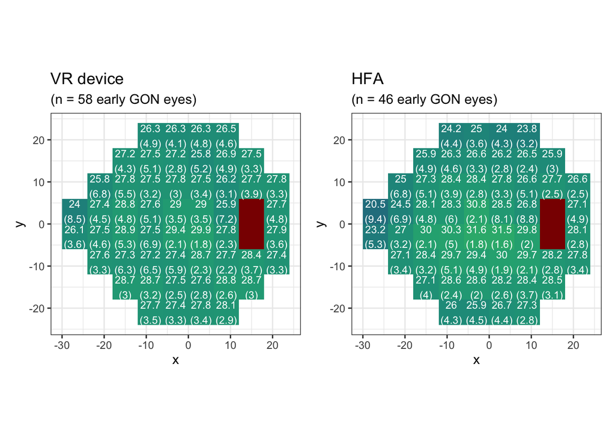

```r
diffplot_advancedGON <- meanSensitivity %>%
  mutate(diff = meanRT-meanHFA) %>%
  ggplot(aes(x, y, diff)) +
  geom_raster(aes(x = x, y = y, fill = diff)) +
  geom_text(aes(label = ifelse(is.na(diff), "", paste0(round(diff, 2))),
                x = x, y = y), size = 3, colour="black") +
  coord_fixed(ratio = 1) +
  scale_fill_gradientn(colours = colorRampPalette(c("red", "white", "red"))(27), limits = c(-13, 13),
                       na.value="darkred") +
  theme_bw() +
  ggtitle("Difference (VR device-HFA)") +
  theme(legend.position="none")

pplot_advancedGON <- meanSensitivity %>%
  mutate(
    diff = meanRT - meanHFA,

    # 1. BACKGROUND COLORS (Red-Blue Palette)
    box_color = case_when(
      is.na(pvalue) ~ "white",

      # --- COOL COLORS (Blue) ---
      diff > 0 & pvalue < 0.001 ~ "#0571b0",  # Dark Blue
      diff > 0 & pvalue < 0.01  ~ "#92c5de",  # Medium Blue
      diff > 0 & pvalue < 0.05  ~ "#d1e5f0",  # Pale Blue

      # --- WARM COLORS (Red) ---
      diff <= 0 & pvalue < 0.001 ~ "#ca0020", # Dark Red
      diff <= 0 & pvalue < 0.01  ~ "#f4a582", # Medium Red
      diff <= 0 & pvalue < 0.05  ~ "#fddbc7", # Pale Red

      TRUE ~ "white"
    ),

    # 2. TEXT COLOR LOGIC
    # ONLY turn white if p < 0.001 (Darkest boxes)
    text_color = case_when(
      pvalue < 0.001 ~ "white",
      TRUE           ~ "black"
    )
  ) %>%
  ggplot(aes(x, y)) +
  geom_tile(aes(fill = box_color), colour = "grey90") +
  scale_fill_identity() +

  # 3. THE FIX: Note that 'colour = text_color' is INSIDE aes()
  # and there is NO colour="black" outside aes()
  geom_text(aes(label = ifelse(is.na(pvalue), "",
                        ifelse(pvalue < 0.001, "<.001",
                        ifelse(pvalue < 0.01, "<.01", round(pvalue, 2)))),
                x = x, y = y,
                colour = text_color),
            size = 3) +

  # 4. Tell ggplot to use the "white"/"black" strings as real colors
  scale_colour_identity() +

  coord_fixed(ratio = 1) +
  theme_bw() +
  ggtitle("Wilcoxon p-values (VR device - HFA)",
          subtitle = "Warm = VR < HFA | Cool = VR > HFA") +
  theme(legend.position="none",
        panel.grid = element_blank())

# Plot using the STRICT Bonferroni values
pplot_bonferroni_advancedGON <- meanSensitivity %>%
  mutate(box_color = case_when(
    p_bonferroni < 0.001 ~ "red",
    p_bonferroni < 0.01  ~ "orange",
    p_bonferroni < 0.05  ~ "yellow",
    TRUE                 ~ "white"
  )) %>%
  ggplot(aes(x, y)) +
  geom_tile(aes(fill = box_color), colour = "grey90") +
  scale_fill_identity() +
  geom_text(aes(label = ifelse(p_bonferroni < 0.001, "<.001",
                        ifelse(p_bonferroni < 0.01, "<.01", round(p_bonferroni, 2))),
                x = x, y = y), size = 3, colour="black") +
  coord_fixed(ratio = 1) +
  theme_bw() +
  ggtitle("Bonferroni Corrected") +
  theme(legend.position="none", panel.grid = element_blank())

# rtplot_earlyGON + hfaplot_earlyGON
# ggsave("plots/earlygon.png", width = 10, height = 6)
#
# rtplot_moderateGON + hfaplot_moderateGON
# ggsave("plots/moderategon.png", width = 10, height = 6)
#
# rtplot_advancedGON + hfaplot_advancedGON
# ggsave("plots/advancedgon.png", width = 10, height = 6)
#
# rtplot_earlyGON + hfaplot_earlyGON + diffplot_earlyGON
# ggsave("plots/earlygon_withdiff.png", width = 14, height = 6)
#
# rtplot_moderateGON + hfaplot_moderateGON + diffplot_moderateGON
# ggsave("plots/moderategon_withdiff.png", width = 14, height = 6)
#
# rtplot_advancedGON + hfaplot_advancedGON + diffplot_advancedGON
# ggsave("plots/advancedgon_withdiff.png", width = 14, height = 6)

# rtplot_earlyGON + hfaplot_earlyGON + pplot_earlyGON
# ggsave("plots/earlygon_withpcolours.png", width = 14, height = 6)
#
# rtplot_moderateGON + hfaplot_moderateGON + pplot_moderateGON
# ggsave("plots/moderategon_withpcolours.png", width = 14, height = 6)
#
# rtplot_advancedGON + hfaplot_advancedGON + pplot_advancedGON
# ggsave("plots/advancedgon_withpcolours.png", width = 14, height = 6)

rtplot_earlyGON + hfaplot_earlyGON
```

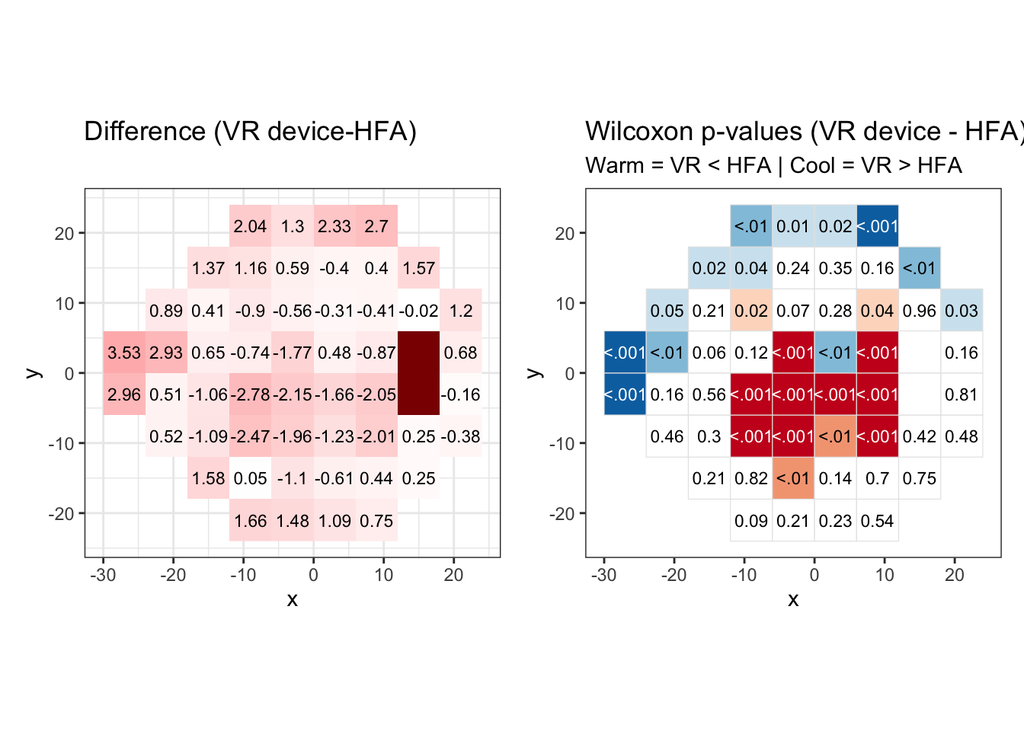

```r
diffplot_earlyGON+ pplot_earlyGON
```

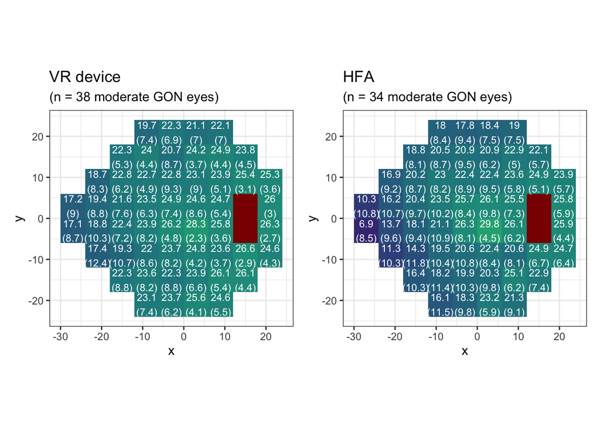

```r
rtplot_moderateGON + hfaplot_moderateGON
```

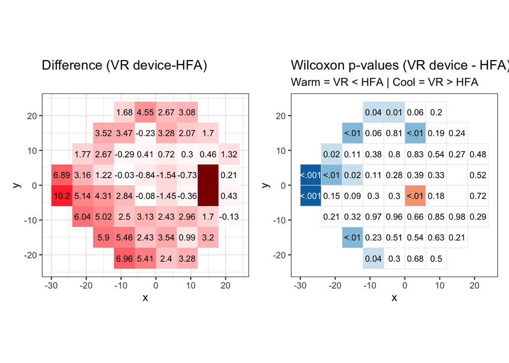

```r
diffplot_moderateGON + pplot_moderateGON
```

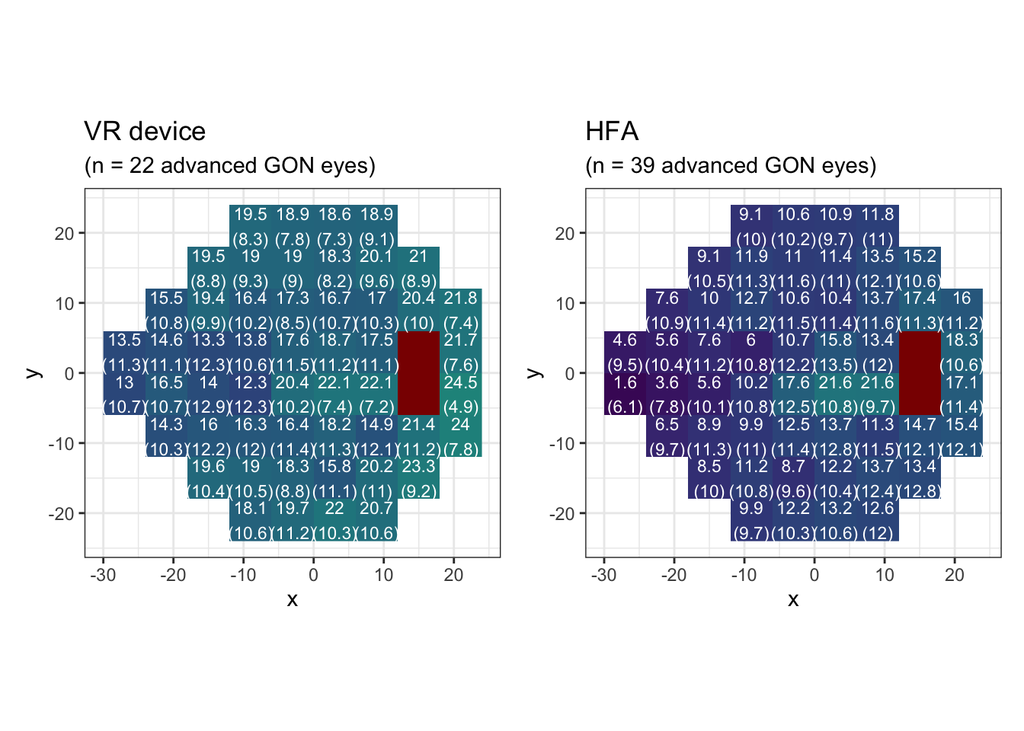

```r
rtplot_advancedGON + hfaplot_advancedGON
```

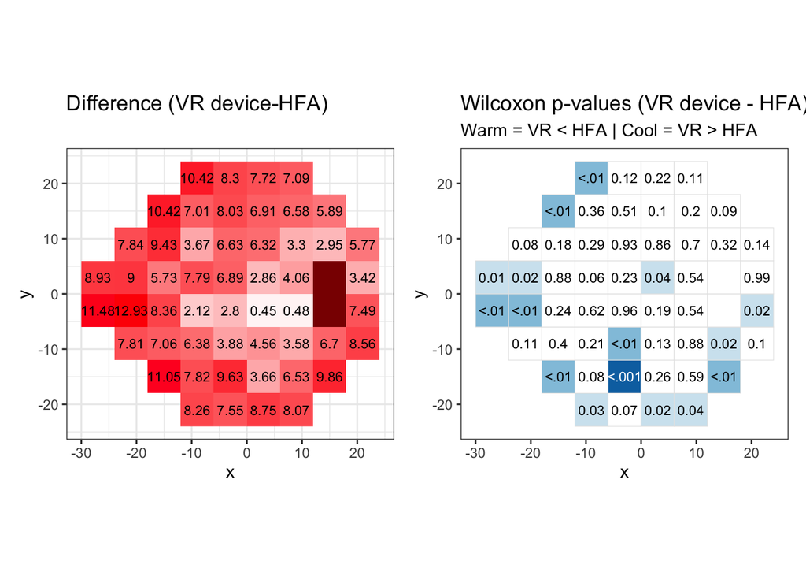

```r
diffplot_advancedGON + pplot_advancedGON
```

### Scotoma analysis

Please refer to [link](https://vvnejl.github.io/retinalogik-study/scotoma_analysis.html).

### Test duration

> The duration of the RL-VF was significantly shorter than that of the Humphrey and did not vary with glaucoma severity in a similar manner to SAP administered with the HFA.

```r
duration <- dBdat_filtered %>%
  group_by(classification, device) %>%
  mutate(duration = as.duration(duration)) %>%
  mutate(mean = mean(duration)/60,
         sd = sd(duration)/60,
         median = median(duration)/60,
         iqr_q1 = quantile(duration, .25)/60,
         iqr_q3 = quantile(duration, .75)/60) %>%
  distinct(classification, device, mean, sd, median, iqr_q1, iqr_q3)

duration %>%
  mutate(classification = factor(classification, levels = c("Mild", "Moderate", "Advanced")),
         device = factor(device, levels = c("retinalogik", "hfa"))) %>%
  arrange(classification, device) %>%
  nice_table()
```

| classification | device | mean | sd | median | iqr_q1 | iqr_q3 |
| --- | --- | --- | --- | --- | --- | --- |
| Mild | retinalogik | 3.65 | 0.33 | 3.57 | 3.40 | 3.77 |
| Mild | hfa | 5.38 | 0.78 | 5.07 | 4.80 | 5.98 |
| Moderate | retinalogik | 4.33 | 0.40 | 4.27 | 4.03 | 4.68 |
| Moderate | hfa | 7.00 | 0.79 | 6.81 | 6.38 | 7.60 |
| Advanced | retinalogik | 5.33 | 1.10 | 5.12 | 4.45 | 5.98 |
| Advanced | hfa | 6.84 | 0.75 | 6.80 | 6.33 | 7.22 |

```r
durationdat <- dBdat_filtered %>%
  group_by(id, device) %>%
  mutate(duration = mean(as.duration(duration))) %>%
  distinct(id, classification, device, duration) %>%
  pivot_wider(names_from = device, values_from = duration) %>%
  na.omit()

durationtest <- wilcox.test(durationdat$retinalogik, durationdat$hfa, paired=TRUE)
```

Median test duration time was 4.09 (IQR = 3.64, 4.6) mins for Retinalogik and 6.35 (IQR = 5.6, 6.89) mins for HFA. Wilcoxon signed rank test indicated that this 2.26 mins difference was statistically significant, *V* = 16, $p < 0.01$.

### ICC

```r
# ICC (1,3) Agreement between tests comparing "retinalogik" and "hfa" measurements.
dB_wide_agreement <- dBdat_filtered %>%
  group_by(id, device) %>%
  summarise(mean_dB = mean(dB, na.rm = TRUE)) %>%
  pivot_wider(names_from = device, values_from = mean_dB)
> `summarise()` has regrouped the output.
> ℹ Summaries were computed grouped by id and device.
> ℹ Output is grouped by id.
> ℹ Use `summarise(.groups = "drop_last")` to silence this message.
> ℹ Use `summarise(.by = c(id, device))` for per-operation grouping
>   (`?dplyr::dplyr_by`) instead.

icc_data_agreement <- dB_wide_agreement %>%
  ungroup() %>%
  select(retinalogik, hfa) %>%
  mutate(
    retinalogik = as.numeric(retinalogik),
    hfa = as.numeric(hfa)
  ) %>%
  as.matrix()

#icc_result_1_3 <- ICC(icc_data_agreement, lmer = FALSE, missing=FALSE) # lmer=FALSE for base R stats
icc_result_1_3 <- ICC(icc_data_agreement, lmer = TRUE, missing=FALSE)
# use result from ICC3 Single_fixed_raters, e.g.,
# Single_fixed_raters      ICC3 0.93 27  32  32 1.4e-15        0.86        0.96

### For repeatability within a device
retinalogik_visits <- dBdat_filtered %>%
  filter(device == "retinalogik") %>%
  # If you have varying numbers of visits, you might need to pad with NA or take a consistent number.
  # For demonstration, let's assume we pivot directly.
  # It's crucial that 'visit' actually represents repeated measures of the *same thing* to be averaged.
  group_by(id, visit) %>%
  summarise(mean_dB_visit = mean(dB, na.rm = TRUE)) %>% # If multiple dB per id, visit, device
  pivot_wider(names_from = visit, values_from = mean_dB_visit, names_prefix = "Visit_") %>%
  ungroup() # Ungroup after pivot_wider
> `summarise()` has regrouped the output.
> ℹ Summaries were computed grouped by id and visit.
> ℹ Output is grouped by id.
> ℹ Use `summarise(.groups = "drop_last")` to silence this message.
> ℹ Use `summarise(.by = c(id, visit))` for per-operation grouping
>   (`?dplyr::dplyr_by`) instead.

icc_data_retinalogik <- retinalogik_visits %>%
  select(starts_with("Visit_")) %>%
  as.matrix()

icc_result_1_2_retinalogik <- ICC(icc_data_retinalogik)
icc_result_1_2_retinalogik # use ICC2k results
> Call: ICC(x = icc_data_retinalogik)
>
> Intraclass correlation coefficients
>                          type  ICC   F df1 df2       p lower bound upper bound
> Single_raters_absolute   ICC1 0.97  97  44  90 7.9e-60        0.95        0.98
> Single_random_raters     ICC2 0.97 103  44  88 8.4e-60        0.95        0.98
> Single_fixed_raters      ICC3 0.97 103  44  88 8.4e-60        0.95        0.98
> Average_raters_absolute ICC1k 0.99  97  44  90 7.9e-60        0.98        0.99
> Average_random_raters   ICC2k 0.99 103  44  88 8.4e-60        0.98        0.99
> Average_fixed_raters    ICC3k 0.99 103  44  88 8.4e-60        0.98        0.99
>
>  Number of subjects = 45     Number of Judges =  3
> See the help file for a discussion of the other 4 McGraw and Wong estimates,

# repeat for HFA
hfa_visits <- dBdat_filtered %>%
  filter(device == "hfa") %>%
  group_by(id, visit) %>%
  summarise(mean_dB_visit = mean(dB, na.rm = TRUE)) %>%
  pivot_wider(names_from = visit, values_from = mean_dB_visit, names_prefix = "Visit_") %>%
  ungroup()
> `summarise()` has regrouped the output.
> ℹ Summaries were computed grouped by id and visit.
> ℹ Output is grouped by id.
> ℹ Use `summarise(.groups = "drop_last")` to silence this message.
> ℹ Use `summarise(.by = c(id, visit))` for per-operation grouping
>   (`?dplyr::dplyr_by`) instead.

icc_data_hfa <- hfa_visits %>%
  select(starts_with("Visit_")) %>%
  as.matrix()

icc_result_1_2_hfa <- ICC(icc_data_hfa)
icc_result_1_2_hfa # use ICC2k results
> Call: ICC(x = icc_data_hfa)
>
> Intraclass correlation coefficients
>                          type  ICC  F df1 df2       p lower bound upper bound
> Single_raters_absolute   ICC1 0.96 81  46  94 9.5e-59        0.94        0.98
> Single_random_raters     ICC2 0.96 81  46  92 1.0e-57        0.94        0.98
> Single_fixed_raters      ICC3 0.96 81  46  92 1.0e-57        0.94        0.98
> Average_raters_absolute ICC1k 0.99 81  46  94 9.5e-59        0.98        0.99
> Average_random_raters   ICC2k 0.99 81  46  92 1.0e-57        0.98        0.99
> Average_fixed_raters    ICC3k 0.99 81  46  92 1.0e-57        0.98        0.99
>
>  Number of subjects = 47     Number of Judges =  3
> See the help file for a discussion of the other 4 McGraw and Wong estimates,
```

### Questionnaire

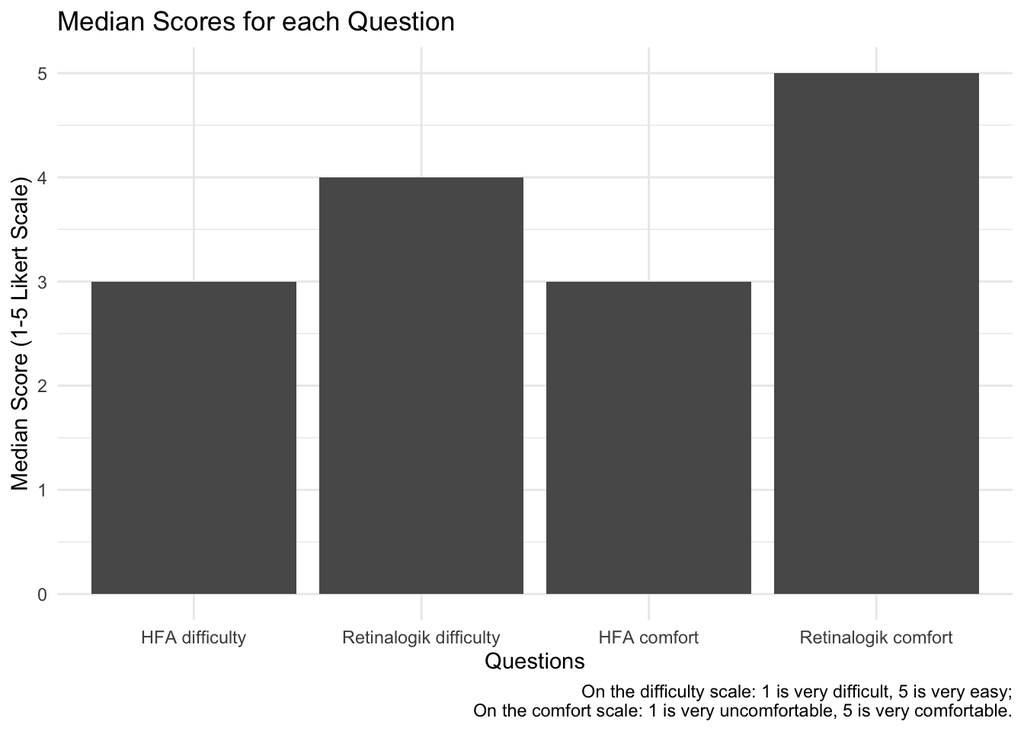

```r
qdat <- read.csv("RetinaLogik Questionnaire Data(Sheet1).csv") %>%
  mutate(
    # Extract the numeric part after "RL"
    numeric_part = as.numeric(str_extract(Patient.ID, "\\d+")),
    # Format the numeric part to have at least two digits with leading zeros
    formatted_numeric = str_pad(numeric_part, width = 2, side = "left", pad = "0"),
    # Combine "RL" with the formatted number
    ID = paste0("RL", formatted_numeric)
  ) %>%
  select(-Patient.ID)

# Recode the columns
qdat_numeric <- qdat %>%
  mutate(
    Q1..Desktop.difficulty = case_match(Q1..Desktop.difficulty,
      "very easy" ~ 5,
      "somewhat easy" ~ 4,
      "neutral" ~ 3,
      "somewhat difficult" ~ 2,
      "very difficult" ~ 1
    ),
    Q2..Head.mounted.difficulty = case_match(Q2..Head.mounted.difficulty,
      "very easy" ~ 5,
      "somewhat easy" ~ 4,
      "neutral" ~ 3,
      "somewhat difficult" ~ 2,
      "very difficult" ~ 1
    ),
    Q3..Desktop.comfort = case_match(Q3..Desktop.comfort,
      "very comfortable" ~ 5,
      "somewhat comfortable" ~ 4,
      "neutral" ~ 3,
      "somewhat uncomfortable" ~ 2,
      "very uncomfortable" ~ 1
    ),
    Q4..Head.mounted.comfort = case_match(Q4..Head.mounted.comfort,
      "very comfortable" ~ 5,
      "somewhat comfortable" ~ 4,
      "neutral" ~ 3,
      "somewhat uncomfortable" ~ 2,
      "very uncomfortable" ~ 1
    )
  )
> Warning: There was 1 warning in `mutate()`.
> ℹ In argument: `Q1..Desktop.difficulty = case_match(...)`.
> Caused by warning:
> ! `case_match()` was deprecated in dplyr 1.2.0.
> ℹ Please use `recode_values()` instead.

summary_stats <- qdat_numeric %>%
  summarise(
    Med_Q1 = median(Q1..Desktop.difficulty, na.rm = TRUE),
    SD_Q1 = sd(Q1..Desktop.difficulty, na.rm = TRUE),
    Med_Q2 = median(Q2..Head.mounted.difficulty, na.rm = TRUE),
    SD_Q2 = sd(Q2..Head.mounted.difficulty, na.rm = TRUE),
    Med_Q3 = median(Q3..Desktop.comfort, na.rm = TRUE),
    SD_Q3 = sd(Q3..Desktop.comfort, na.rm = TRUE),
    Med_Q4 = median(Q4..Head.mounted.comfort, na.rm = TRUE),
    SD_Q4 = sd(Q4..Head.mounted.comfort, na.rm = TRUE)
  )

print(summary_stats)
>   Med_Q1    SD_Q1 Med_Q2     SD_Q2 Med_Q3    SD_Q3 Med_Q4     SD_Q4
> 1      3 1.094708      4 0.9518305      3 1.126446      5 0.8200282

patient_summary <- qdat_numeric %>%
  group_by(ID) %>%
  summarise(
    Med_Q1 = median(Q1..Desktop.difficulty, na.rm = TRUE),
    Med_Q2 = median(Q2..Head.mounted.difficulty, na.rm = TRUE),
    Med_Q3 = median(Q3..Desktop.comfort, na.rm = TRUE),
    Med_Q4 = median(Q4..Head.mounted.comfort, na.rm = TRUE)
  )

print(patient_summary)
> # A tibble: 54 × 5
>    ID    Med_Q1 Med_Q2 Med_Q3 Med_Q4
>    <chr>  <dbl>  <dbl>  <dbl>  <dbl>
>  1 RL01       5      5      5      5
>  2 RL02       2      4      2      4
>  3 RL03       2      4      2      5
>  4 RL04       2      3      3      4
>  5 RL06       4      4      3      4
>  6 RL07       2      4      2      4
>  7 RL08       2      4      2      4
>  8 RL10       2      4      2      5
>  9 RL11       2      4      2      5
> 10 RL12       4      5      3      4
> # ℹ 44 more rows

questionnaire_plot <- summary_stats %>%
  tidyr::pivot_longer(
    cols = c(Med_Q1, Med_Q2, Med_Q3, Med_Q4),
    names_to = "Question",
    values_to = "Median_Score"
  )

questionnaire_plot %>%
  ggplot(aes(x = Question, y = Median_Score)) +
  geom_bar(stat = "identity", position = position_dodge()) +
  labs(
    title = "Median Scores for each Question",
    x = "Questions",
    y = "Median Score (1-5 Likert Scale)",
    caption = "On the difficulty scale: 1 is very difficult, 5 is very easy;
    On the comfort scale: 1 is very uncomfortable, 5 is very comfortable."
  ) +
  scale_x_discrete(labels = c("HFA difficulty", "Retinalogik difficulty",
                              "HFA comfort", "Retinalogik comfort")) +
  theme_minimal()
```

```r
# Wilcoxon signed-rank test
wilcox_difficulty <- wilcox.test(qdat_numeric$Q1..Desktop.difficulty,
                                 qdat_numeric$Q2..Head.mounted.difficulty,
                                 paired = TRUE)

wilcox_comfort <- wilcox.test(qdat_numeric$Q3..Desktop.comfort,
                              qdat_numeric$Q4..Head.mounted.comfort,
                              paired = TRUE)

q5dat <- qdat %>%
  select(ID, Q5..Overall.preference) %>%
  mutate(Q5..Overall.preference = as.factor(Q5..Overall.preference))

q5dat <- q5dat[q5dat$Q5..Overall.preference != "", ] %>%
  count(Q5..Overall.preference)
```

Report by [Vivian Eng](https://ca.linkedin.com/in/vivianjleng)

*vivian@eadietech.com*